# Where the New Rail Lines Will Draw Their Riders From

A Huff model of weekday morning ridership for the Jurong Region Line and Cross Island Line

ZeXin Chen

15 November 2026

## Contents

**Part 1, The Question and the Data**

- Where morning riders board today
- How the analysis works

**Part 2, Calibrating the Huff Model**

- Insight 1, distance and station features explain most of the pattern

**Part 3, The New Lines**

- Insight 2, eight new stations draw half the riders, and up to two in five are quieter than Hume
- Insight 3, the impact stays near the new lines
- Insight 4, about one in eight flats gets a new most likely station

**Part 4, Bonus**

- Insight 5, the ranking holds under another decay curve

**Part 5, So What**

- Key findings and limits
- Rail planning implications

## Morning riders board in the HDB towns, and two new lines are coming

Part 1 · The question and the data

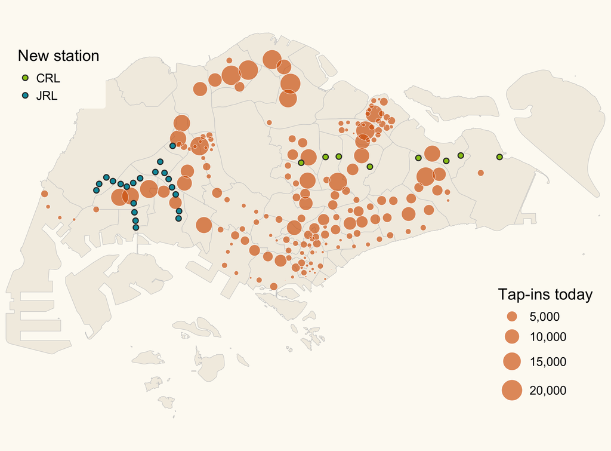

Research question

How many morning riders will each new JRL and CRL station draw, which may be too quiet to open yet, and which existing stations will lose riders?

717,000

weekday tap-ins, 6am to 9am, at 184 stations

29

new station points, plus 7 interchanges that gain a line

**Data.** LTA origin-destination volumes for August and September 2026, station and bus stop layers, 10,817 HDB blocks with their flats, and the future station points.

**Unit.** An HDB block is an origin, sized by its flats. A station is a destination.

## Fix the data land mines, then fit a Huff model

Part 1 · The question and the data

Land mines that would mislead the model

**No key between HDB tables.** Flats and block outlines had no shared column. OneMap search turned each address into a postal code that links them.

**Interchange codes did not match.** “NS24/NE6/CC1” in the ridership file is three labels in the station layer. Matched code by code.

**Codes that do not line up.** Circle Line stations were recoded in July, so only August and September are used. Stevens appears under two codes, DT10 and TE11, which are merged.

**New blocks missing.** Tengah blocks finished after the building layer are placed with OneMap’s points, so the JRL’s newest town is not lost.

| Step | Question | Method |
| --- | --- | --- |
| **Task 2** | What makes people pick a station? | Huff model, weights fitted to observed tap-in shares |
| **Task 3** | How many riders will each new station draw? | Same model with the new stations added |
| **Task 3** | Which stations lose riders, and which blocks switch? | Change in predicted tap-ins and most likely station |
| **Bonus** | Does the decay curve change the answer? | Exponential instead of power decay |

Each block considers stations within 5 km. Without this limit, a new station in Jurong would take riders from Changi. Total morning demand is held at today’s level.

## Insight 1. Distance, lines and LRT status explain most of the pattern

Part 2 · Calibrating the Huff model

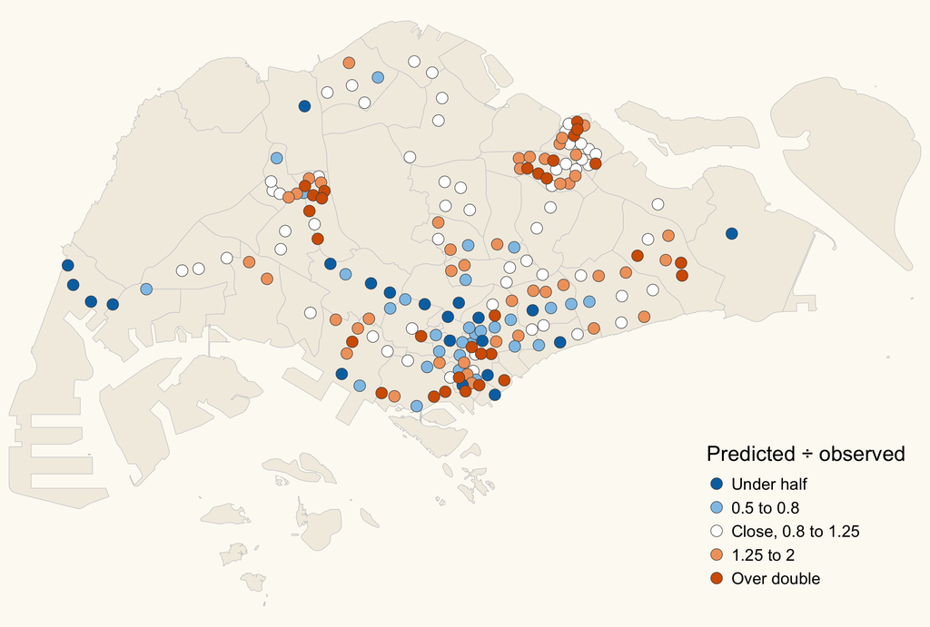

84%

of the variation in tap-ins between stations explained

2.05

distance decay λ. Twice as far keeps 24% of the pull

**Beats both references.** Nearest station only explains 55%, distance only 57%. Lines and LRT status add the rest. An LRT stop has 12% of an MRT station’s pull.

**Too low, in blue.** Near private homes, such as Newton and the Bukit Timah corridor, and where riders are workers, such as Kranji, Tuas and Changi Airport.

**Too high, in orange.** Most LRT stops in Punggol, Sengkang and Bukit Panjang, whose residents often bus straight to the MRT, and MRT stations next to a busier neighbour, such as Expo.

## Insight 2. Eight new stations draw half the riders, and up to two in five are quieter than Hume

Part 3 · The new lines

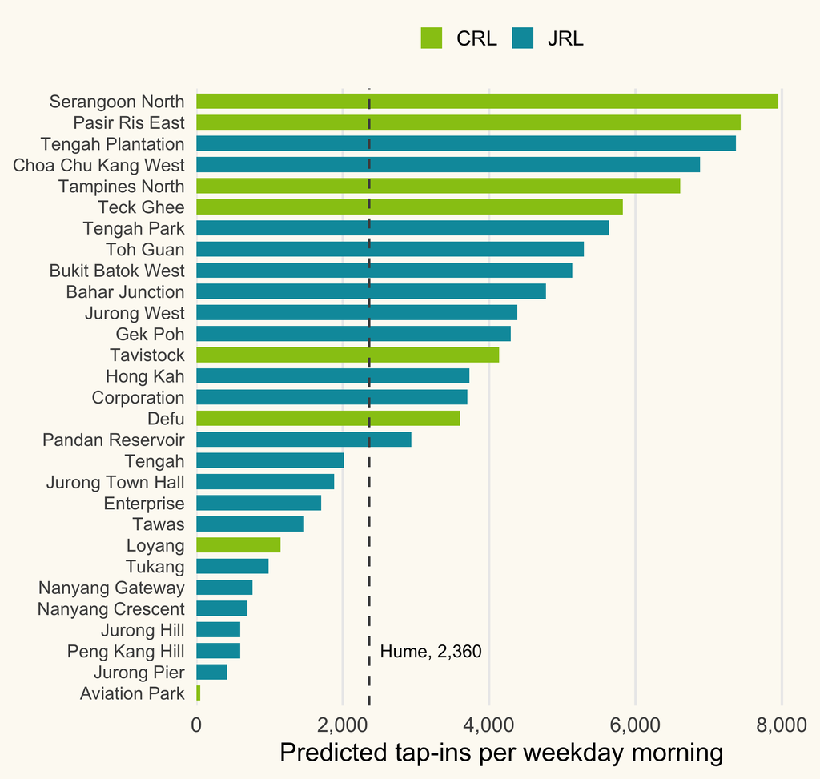

102,100

weekday morning tap-ins at the 29 new stations, 14% of today’s total

36%

of them at the top 5, led by Serangoon North, Pasir Ris East and Tengah Plantation

**Below Hume.** Hume was kept closed for ten years. The model gives it 2,360 tap-ins, and 12 new stations fall below that. 7 are below even Hume’s observed 1,000, all at NTU, in the Jurong industrial area or at Changi.

These stations will mainly serve workers and students, whom the model does not count, so their opening case rests on that demand.

## Insight 3. New riders come from nearby, and the rest barely changes

Part 3 · The new lines

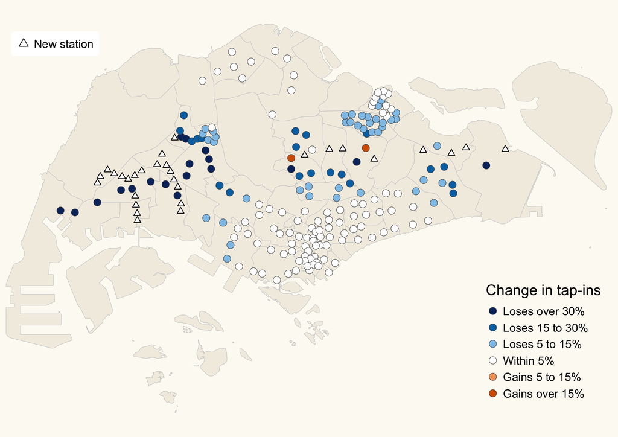

101

of 182 existing stations with predicted riders change by less than 5%

38

lose more than 15%

**Biggest loser.** The East-West Line from Jurong East to Tuas gives up about 39,100 tap-ins, as the JRL runs parallel just to its north.

**Interchanges differ.** Hougang and Bright Hill gain from their new CRL line, and Ang Mo Kio holds steady. Jurong East, Boon Lay, Choa Chu Kang and Pasir Ris lose, because new stations sit in their outer catchments.

The East-West Line losses are likely too high. The model does not know that riders bound for the city may stay on that line.

## Insight 4. About one in eight HDB flats gets a new most likely station

Part 3 · The new lines

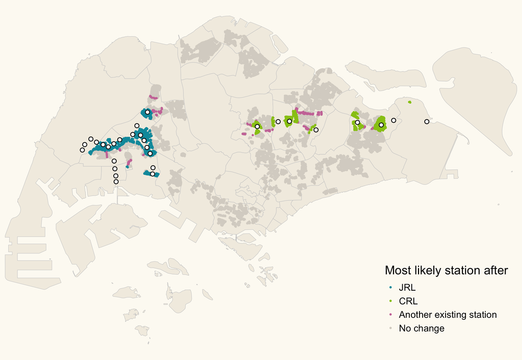

8%

of HDB flats switch to a JRL station

4%

switch to a CRL station

**Where.** Most in Jurong West, Jurong East, Tengah, Pasir Ris and Bukit Batok, then Choa Chu Kang, Ang Mo Kio and Serangoon.

**One-sided cuts.** A catchment like Lakeside’s or Tampines’ shrinks on the side facing the new line, while blocks next to the old station stay with it.

## Insight 5. The station ranking holds under another distance decay curve

Part 4 · Bonus

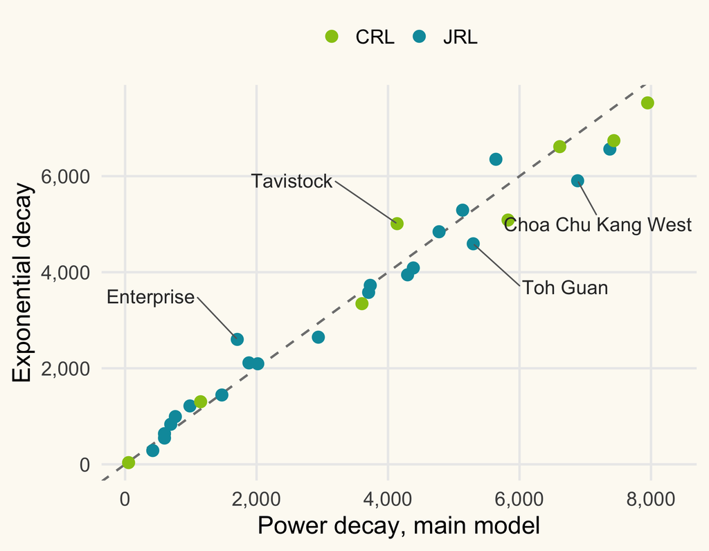

Question

Do the predictions depend on the shape of distance decay?

0.99

rank correlation for the new stations

0.98

for the change at existing stations

**Method.** e<sup>−λd</sup> instead of d<sup>−λ</sup>, refitted with the same data, the same 5 km limit and the same target.

**Answer.** Same ranking, similar total, 100,000 against 102,100. Single stations can differ by up to 52%, so read each number as a range.

## Key findings and their limits

Part 5 · So what

|  | Finding | Evidence | Main limit |
| --- | --- | --- | --- |
| **1** | Station choice follows distance, lines and LRT status | R² 0.84, λ 2.05, weights fitted to observed tap-in shares | Only HDB residents are origins, so stations near private homes and workplaces are under-predicted |
| **2** | The 29 new stations draw about 102,100 morning riders. 7 to 12 of them draw fewer than Hume | Led by Serangoon North, Pasir Ris East and Tengah Plantation | Total demand held fixed, so new bus-to-rail riders are not counted |
| **3** | The impact is local | 101 of 182 stations change by under 5% | Rests on the choice limit. Limits of 3 to 8 km give 35 to 42 stations losing over 15% |
| **4** | The East-West Line through Jurong loses most | About 39,100 tap-ins | Probably too high, because travel direction is not modelled |
| **5** | The ranking is robust | Rank correlation 0.99 with an exponential curve | Straight-line distance, not real routes |

**Main finding.** The new lines move morning riders into the housing gaps between today’s lines, and the effect on the rest of the network stays local.

## Rail planning implications

Part 5 · So what

**Plan the biggest entrances and feeder links at Serangoon North, Pasir Ris East and Tengah Plantation**

Becausethey draw the most morning riders among the new stations

Check firstTengah’s population once all its flats are built, since the model only sees completed blocks

**Build the shell now, choose the opening date later, for the quietest stations**

Because7 to 12 new stations draw fewer home-based riders than Hume, which stayed closed for ten years

Check firstworker, student and airport staff numbers from JTC, NTU and Changi Airport Group

**Use the relief on the East-West Line through Jurong**

Becauseit gives up about 39,100 morning boardings to the JRL

Check firstwhether city-bound riders really change at Jurong East or Boon Lay, using JRL data once it opens

**Re-route feeder buses and check interchange capacity**

Becauseabout one in eight flats gets a new most likely station, and Hougang gains the most riders among the interchanges

Check firstcurrent feeder routes and transfer space at Hougang, Bright Hill and Ang Mo Kio

The model shows where morning riders from HDB homes are likely to board. It does not count new riders who take the bus today.

## References

1. Bahrami, M. et al. (2022). Using gravity model to make store closing decisions, a data driven approach. *Expert Systems with Applications*, 205, 117703.
2. Bai, L. et al. (2023). Delineating hierarchical obstetric hospital service areas using the Huff model based on medical records. *Applied Geography*, 153, 102903.
3. Fotheringham, A. S. and O’Kelly, M. E. (1989). *Spatial Interaction Models: Formulations and Applications*. Kluwer Academic.
4. Huff, D. L. (1963). A probabilistic analysis of shopping center trade areas. *Land Economics*, 39(1), 81 to 88.
5. Kam, T. S. (2026). *R for Geospatial Data Science and Analytics*. https://r4gdsa.netlify.app/
6. Kam, T. S. (2026). *ISSS626 Lesson 8, Market Area Analysis for Retail and Service Locations, Huff and MCI Models*. Singapore Management University.
7. Land Transport Authority (2026). *Factsheet: The Next Phase of Rail Development*.
8. Lin, T. G. et al. (2016). Enhanced Huff model for estimating Park and Ride catchment areas in Perth, WA. *Journal of Transport Geography*, 54, 336 to 348.
9. Nakanishi, M. and Cooper, L. G. (1974). Parameter estimation for a multiplicative competitive interaction model, least squares approach. *Journal of Marketing Research*, 11(3), 303 to 311.
10. Wieland, T. (2017). Market area analysis for retail and service locations with MCI. *The R Journal*, 9(1), 298 to 323.
11. Zhu, Z. et al. (2021). Improved Huff model for estimating urban rail transit station catchment areas considering station choices. *Journal of Advanced Transportation*, 2021.

Data from LTA DataMall, HDB, data.gov.sg, OneMap and Elliot Wu’s station coordinates. Full code, checks and workflow in the Technical Report.